# Grade Data Analysis

Elif Beyza Asan

2025-07-12

## 1. Introduction

This report presents a comprehensive analysis of student academic performance spanning over 15 years of educational data. The dataset contains information about students across multiple departments, courses, and semesters, providing a unique opportunity to uncover patterns and relationships that influence academic success.

My analysis focuses on understanding how various factors—including attendance, midterm performance, departmental differences, and temporal trends—interact to shape final academic outcomes. Through careful data preprocessing, normalization, and visualization, I aim to tell a compelling story about what drives student success in higher education.

## 2. Data Overview and Initial Exploration

Let’s begin by loading and examining our dataset to understand its structure and characteristics.

```r
# Load the dataset
grades <- read.csv("grades.csv", as.is = TRUE)

# Display basic information about the dataset
# Dataset dimensions and column names will be shown in the text below
head(grades)
```

```
##   X Year Semester CourseCode   ID Department Midterm Final LetterGrade
## 1 1 2023     Fall   Course 1  914       ECON      25    35          C-
## 2 2 2023     Fall   Course 2 1132       CTIS      55    53           C
## 3 3 2023   Spring   Course 1  669       ECON      14    14           C
## 4 4 2023   Spring   Course 1  587       ECON      16    12          C-
## 5 5 2023     Fall   Course 2 1089       CTIS      32    31           F
## 6 6 2023   Spring   Course 3 1134       ECON      58    66          C+
##   Attendance
## 1     0.1190
## 2     0.3600
## 3         NA
## 4         NA
## 5     0.4000
## 6     0.5714
```

#### Dataset Overview:

- Dimensions: 1417 rows and 10 columns
- Columns: X, Year, Semester, CourseCode, ID, Department, Midterm, Final, LetterGrade, Attendance

### 2.1 Summary Statistics

The summary statistics give a general picture of the dataset.

- The Year variable ranges from 2010 to 2024, suggesting that the data spans over 14 academic years.
- Midterm and Final scores range from 0 to 100, but many values are missing—87 for midterms and 195 for finals.
- The average midterm score is around 35.5 and the average final score is about 43.3, indicating a relatively low performance overall.
- The Attendance variable shows a wide range (0 to 1), with a mean close to 0.52, but also has a significant number of missing values (240).
- Categorical variables like CourseCode, Department, and LetterGrade are not summarized numerically but indicate the structure and completeness of the data.

Overall, this summary helps identify missing values and provides insight into the distribution of numeric variables like exam scores and attendance.

```r
# Summary statistics for all variables
summary(grades)
```

```
##        X             Year        Semester          CourseCode
##  Min.   :   1   Min.   :2010   Length:1417        Length:1417
##  1st Qu.: 355   1st Qu.:2018   Class :character   Class :character
##  Median : 709   Median :2023   Mode  :character   Mode  :character
##  Mean   : 709   Mean   :2020
##  3rd Qu.:1063   3rd Qu.:2023
##  Max.   :1417   Max.   :2024
##
##        ID          Department           Midterm           Final
##  Min.   :   1.0   Length:1417        Min.   :  0.00   Min.   :  0.00
##  1st Qu.: 333.0   Class :character   1st Qu.: 17.00   1st Qu.: 22.00
##  Median : 641.0   Mode  :character   Median : 31.00   Median : 40.00
##  Mean   : 641.8                      Mean   : 35.51   Mean   : 43.29
##  3rd Qu.: 950.0                      3rd Qu.: 51.00   3rd Qu.: 63.00
##  Max.   :1289.0                      Max.   :100.00   Max.   :100.00
##                                      NA's   :87       NA's   :195
##  LetterGrade          Attendance
##  Length:1417        Min.   :0.0000
##  Class :character   1st Qu.:0.2553
##  Mode  :character   Median :0.5400
##                     Mean   :0.5193
##                     3rd Qu.:0.7679
##                     Max.   :1.0000
##                     NA's   :240
```

### 2.2 Removing Row Numbers

Row numbers (X) do not carry meaningful information and are removed to keep the dataset clean.

```r
# Remove row numbers column if it exists
if (names(grades)[1] == "X" || names(grades)[1] == "") {
     grades <- grades[, -1]
}
```

#### Key Observations:

- The dataset spans 15 years of academic data
- It includes 20 different departments
- Contains 3 unique courses
- Covers 1417 student records across multiple semesters

## 3. Data Quality and Missing Values Strategy

### 3.1 Missing Values Analysis

Before diving into analysis, I must address data quality issues, particularly missing values, which can significantly impact our findings.

```r
# Analyze missing values
missing_counts <- colSums(is.na(grades))
missing_percentages <- round(missing_counts / nrow(grades) * 100, 2)
missing_summary <- data.frame(
     Variable = names(missing_counts),
     Missing_Count = missing_counts,
     Missing_Percentage = missing_percentages
)
print(missing_summary)
```

```
##                Variable Missing_Count Missing_Percentage
## Year               Year             0               0.00
## Semester       Semester             0               0.00
## CourseCode   CourseCode             0               0.00
## ID                   ID             0               0.00
## Department   Department             0               0.00
## Midterm         Midterm            87               6.14
## Final             Final           195              13.76
## LetterGrade LetterGrade             0               0.00
## Attendance   Attendance           240              16.94
```

#### Missing Values Analysis:

My approach to handling missing values is tailored to each variable’s role in the analysis:

1. Midterm/Final Scores: I replace missing values with the mean score of the same course and semester, preserving course-specific grading patterns.
2. Attendance: I use the median attendance rate within each course, as median is less sensitive to outliers.

```r
# Handle missing Letter Grades first (remove rows)
original_rows <- nrow(grades)
grades <- grades[!is.na(grades$LetterGrade), ]
removed_rows <- original_rows - nrow(grades)

# Function to fill missing values by group
fill_missing <- function(x, group_cols) {
     groups <- do.call(paste, c(group_cols, sep = "_"))
     ave(x, groups, FUN = function(x) {
          x[is.na(x)] <- mean(x, na.rm = TRUE)
          return(x)
     })
}

# Fill missing Midterm scores
grades$Midterm <- fill_missing(
     grades$Midterm,
     list(grades$CourseCode, grades$Semester)
)

# Fill missing Final scores
grades$Final <- fill_missing(
     grades$Final,
     list(grades$CourseCode, grades$Semester)
)

# Fill missing Attendance with course medians
grades$Attendance <- ave(grades$Attendance, grades$CourseCode,
     FUN = function(x) {
          x[is.na(x)] <- median(x, na.rm = TRUE)
          return(x)
     }
)

# Verify no missing values remain in key variables
print("Remaining missing values after cleaning:")
```

```
## [1] "Remaining missing values after cleaning:"
```

```r
print(colSums(is.na(grades)))
```

```
##        Year    Semester  CourseCode          ID  Department     Midterm
##           0           0           0           0           0           0
##       Final LetterGrade  Attendance
##           0           0           0
```

#### Data Cleaning Results:

- Filled missing Midterm and Final scores with course-semester means
- Filled missing Attendance with course medians

## 3.2 Score Normalization: Ensuring Fair Comparisons

Raw scores can be misleading when comparing performance across different courses and semesters due to varying difficulty levels and grading standards. I implement z-score normalization to create fair comparisons.

```r
# Function to calculate z-scores by group
normalize_by_group <- function(x, group_cols) {
     groups <- do.call(paste, c(group_cols, sep = "_"))
     ave(x, groups, FUN = function(x) {
          (x - mean(x, na.rm = TRUE)) / sd(x, na.rm = TRUE)
     })
}

# Normalize Midterm and Final scores within each course & semester
grades$Midterm_norm <- normalize_by_group(
     grades$Midterm,
     list(grades$CourseCode, grades$Semester)
)
grades$Final_norm <- normalize_by_group(
     grades$Final,
     list(grades$CourseCode, grades$Semester)
)
```

#### Normalization Results:

- Midterm - Mean: 0, SD: 0.998
- Final - Mean: 0, SD: 0.998

#### Why I Don’t Normalize Attendance:

Attendance remains unnormalized because: - It’s already on a consistent 0-1 scale - Absolute values are meaningful (e.g., 80% attendance has universal significance) - I want to preserve actual attendance patterns for interpretation

### 3.3 Converting Letter Grades to Numeric Scale

To enable quantitative analysis, I convert letter grades to their GPA equivalents according to the university’s grading system.

```r
# Convert letter grades to numeric values based on university catalog
grades$numeric_grade <- NA
grades$numeric_grade[grades$LetterGrade == "A+"] <- 4.0
grades$numeric_grade[grades$LetterGrade == "A"] <- 4.0
grades$numeric_grade[grades$LetterGrade == "A-"] <- 3.7
grades$numeric_grade[grades$LetterGrade == "B+"] <- 3.3
grades$numeric_grade[grades$LetterGrade == "B"] <- 3.0
grades$numeric_grade[grades$LetterGrade == "B-"] <- 2.7
grades$numeric_grade[grades$LetterGrade == "C+"] <- 2.3
grades$numeric_grade[grades$LetterGrade == "C"] <- 2.0
grades$numeric_grade[grades$LetterGrade == "C-"] <- 1.7
grades$numeric_grade[grades$LetterGrade == "D+"] <- 1.3
grades$numeric_grade[grades$LetterGrade == "D"] <- 1.0
grades$numeric_grade[grades$LetterGrade == "F"] <- 0.0
grades$numeric_grade[grades$LetterGrade == "FX"] <- 0.0
grades$numeric_grade[grades$LetterGrade == "FZ"] <- 0.0

# Replace the original letter grade column
grades <- grades[, !(names(grades) %in% "LetterGrade")]
names(grades)[names(grades) == "numeric_grade"] <- "LetterGrade"

# Display grade distribution
print("Grade Point Distribution:")
```

```
## [1] "Grade Point Distribution:"
```

```r
print(table(grades$LetterGrade))
```

```
##
##   0   1 1.3 1.7   2 2.3 2.7   3 3.3 3.7   4
## 213 149 110 117 153 112 135  99  83  70 108
```

#### Grade Conversion Summary:

Letter grades have been converted to their GPA equivalents according to the university’s grading system.

## 4. Exploring Academic Performance Patterns

Now I dive into the core of our analysis, exploring how different factors influence academic performance across our 15-year dataset.

I begin by examining the scope of our dataset:

- Departments Represented: 20, with a heavy concentration in ECON (939 records), followed by MAN (227) and CTIS (113).
- Courses Analyzed: 3 unique courses (as identified earlier).
- Years Covered: From 2010 to 2024, with most records concentrated in 2023 (499) and 2024 (333).
- Semester Breakdown: Most data comes from the Fall semester (782), followed by Spring (473) and Summer (162). Total Student Records: 1,417. This overview highlights a clear departmental imbalance and a recent increase in data volume, which are important context points for interpreting performance trends.

```r
library(colorspace)

# Basic categorical variable analysis
# Department distribution
dept_dist <- sort(table(grades$Department), decreasing = TRUE)

# Year distribution
year_dist <- table(grades$Year)

# Semester distribution
sem_dist <- table(grades$Semester)
```

#### Academic Landscape Overview:

- Departments in Study: 20
- Unique Courses Analyzed: 3
- Years Covered: 2010 to 2024
- Total Student Records: 1417

#### Students per Department:

```r
print(dept_dist)
```

```
##
##  ECON   MAN  CTIS  PSYC    IE   THM  THMS CTISS    IR  PHIL  LAUD   BIM  IAED
##   939   227   113    46    25    19    14     8     7     4     3     2     2
##   LAW  COMD    CS    EE  HIST  PHYS  POLS
##     2     1     1     1     1     1     1
```

#### Records per Year:

```r
print(year_dist)
```

```
##
## 2010 2011 2012 2014 2017 2018 2019 2022 2023 2024
##  137   58   32   16   68   45  115  114  499  333
```

#### Semester Distribution:

```r
print(sem_dist)
```

```
##
##   Fall Spring Summer
##    782    473    162
```

## 5. Key Performance Insights

This section summarizes the most important findings regarding student performance, with a focus on departmental differences, temporal trends, and the impact of attendance.

```r
# Calculate key performance metrics

# Overall performance metrics
overall_gpa <- round(mean(grades$LetterGrade, na.rm = TRUE), 3)
overall_attendance <- round(mean(grades$Attendance, na.rm = TRUE), 3)

# Departmental performance analysis
dept_performance <- tapply(grades$LetterGrade, grades$Department, mean, na.rm = TRUE)
dept_performance <- sort(dept_performance, decreasing = TRUE)

# Year-over-year trends
year_performance <- tapply(grades$LetterGrade, grades$Year, mean, na.rm = TRUE)
year_correlation <- cor(as.numeric(names(year_performance)), year_performance)

# Attendance impact analysis
high_attendance <- grades[grades$Attendance > 0.8, ]
low_attendance <- grades[grades$Attendance <= 0.8, ]
```

#### Overall Metrics:

- Average GPA: 1.987
- Average Attendance: 0.521

#### Departmental Performance Rankings:

There is a wide disparity in academic success across departments. The highest-performing departments by average GPA are:

```r
for (i in 1:length(dept_performance)) {
     cat(sprintf("%d. %s: %.3f GPA\n", i, names(dept_performance)[i], dept_performance[i]))
}
```

```
## 1. CS: 4.000 GPA
## 2. HIST: 4.000 GPA
## 3. IE: 3.492 GPA
## 4. LAW: 3.350 GPA
## 5. PHYS: 3.300 GPA
## 6. PHIL: 3.100 GPA
## 7. COMD: 3.000 GPA
## 8. POLS: 2.700 GPA
## 9. IAED: 2.650 GPA
## 10. CTIS: 2.347 GPA
## 11. EE: 2.300 GPA
## 12. ECON: 2.054 GPA
## 13. MAN: 1.657 GPA
## 14. IR: 1.629 GPA
## 15. PSYC: 1.325 GPA
## 16. THM: 0.900 GPA
## 17. THMS: 0.515 GPA
## 18. CTISS: 0.400 GPA
## 19. BIM: 0.000 GPA
## 20. LAUD: 0.000 GPA
```

This stark contrast may point to grading policies, course difficulty, or student preparedness differences across departments.

#### Academic Performance Trends by Year:

- Trend: GPA has shown a Declining pattern over the years.
- Correlation between year and GPA: -0.8312872 This suggests that either academic standards have become stricter, or student performance has been dropping over time.

#### Attendance Impact Analysis:

- High Attendance (>80%) Average GPA: 2.744
- Low Attendance (≤80%) Average GPA: 1.826
- Performance Gap: 0.918 GPA points

## 6. Correlation Perspective

To better understand how different variables interact, a correlation analysis was conducted:

```r
# Create correlation matrix for numerical variables
numerical_vars <- grades[, c("Midterm_norm", "Final_norm", "Attendance", "LetterGrade")]
correlation_matrix <- cor(numerical_vars, use = "complete.obs")

# Find strongest relationships
upper_tri <- correlation_matrix
upper_tri[lower.tri(upper_tri, diag = TRUE)] <- NA
max_corr_pos <- which(abs(upper_tri) == max(abs(upper_tri), na.rm = TRUE), arr.ind = TRUE)
max_corr_value <- upper_tri[max_corr_pos]
```

#### Correlation Analysis:

```r
print(round(correlation_matrix, 3))
```

```
##              Midterm_norm Final_norm Attendance LetterGrade
## Midterm_norm        1.000      0.578      0.287       0.771
## Final_norm          0.578      1.000      0.262       0.675
## Attendance          0.287      0.262      1.000       0.449
## LetterGrade         0.771      0.675      0.449       1.000
```

#### Strongest Relationship:

- Midterm_norm ↔︎ LetterGrade = 0.771
- Final scores and attendance also show moderate positive correlations with GPA.

These results emphasize that early academic performance (midterms) is a strong predictor of overall success, followed by final performance and attendance.

## 7. Visual Relationship Analysis

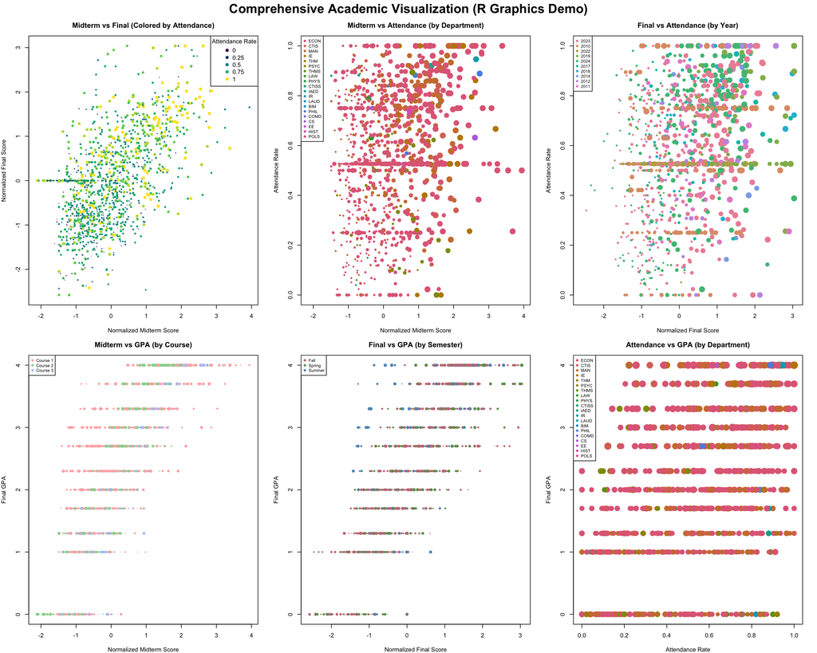

```r
library(colorspace)
set.seed(123)

# Renk paletleri
att_colors <- sequential_hcl(10, palette = "Viridis")  # Attendance için
dept_colors <- qualitative_hcl(length(unique(grades$Department)), palette = "Dark 3")
names(dept_colors) <- unique(grades$Department)

year_colors <- qualitative_hcl(length(unique(grades$Year)), palette = "Set 2")
names(year_colors) <- as.character(unique(grades$Year))

course_colors <- qualitative_hcl(length(unique(grades$CourseCode)), palette = "Set 3")
names(course_colors) <- unique(grades$CourseCode)

sem_colors <- qualitative_hcl(length(unique(grades$Semester)), palette = "Dark 2")
names(sem_colors) <- unique(grades$Semester)

# Attendance'ı 10 parçaya bölerek renklere bağla
att_breaks <- cut(grades$Attendance, breaks = 10, labels = FALSE)

# Grafik düzeni: 2x3
par(mfrow = c(2, 3), mar = c(4, 4, 3, 2), oma = c(0, 0, 2, 0))

# 1. Midterm vs Final (renk: Attendance, boyut: Attendance)
plot(grades$Midterm_norm, grades$Final_norm,
     main = "Midterm vs Final (Colored by Attendance)",
     xlab = "Normalized Midterm Score",
     ylab = "Normalized Final Score",
     pch = 19,
     col = att_colors[att_breaks],
     cex = grades$Attendance)
legend("topright",
       title = "Attendance Rate",
       legend = round(seq(min(grades$Attendance, na.rm = TRUE),
                          max(grades$Attendance, na.rm = TRUE),
                          length.out = 5), 2),
       col = att_colors[seq(1, 10, length.out = 5)],
       pch = 19)

# 2. Midterm vs Attendance (renk: Department, boyut: GPA)
plot(grades$Midterm_norm, grades$Attendance,
     main = "Midterm vs Attendance (by Department)",
     xlab = "Normalized Midterm Score",
     ylab = "Attendance Rate",
     pch = 19,
     col = dept_colors[grades$Department],
     cex = grades$LetterGrade / 2)
legend("topleft", legend = names(dept_colors),
       col = dept_colors, pch = 19, cex = 0.7)

# 3. Final vs Attendance (renk: Year, boyut: GPA)
plot(grades$Final_norm, grades$Attendance,
     main = "Final vs Attendance (by Year)",
     xlab = "Normalized Final Score",
     ylab = "Attendance Rate",
     pch = 19,
     col = year_colors[as.character(grades$Year)],
     cex = grades$LetterGrade / 2)
legend("topleft", legend = names(year_colors),
       col = year_colors, pch = 19, cex = 0.7)

# 4. Midterm vs Letter Grade (renk: Course, boyut: Attendance)
plot(grades$Midterm_norm, grades$LetterGrade,
     main = "Midterm vs GPA (by Course)",
     xlab = "Normalized Midterm Score",
     ylab = "Final GPA",
     pch = 19,
     col = course_colors[grades$CourseCode],
     cex = grades$Attendance)
legend("topleft", legend = names(course_colors),
       col = course_colors, pch = 19, cex = 0.7)

# 5. Final vs Letter Grade (renk: Semester, boyut: Attendance)
plot(grades$Final_norm, grades$LetterGrade,
     main = "Final vs GPA (by Semester)",
     xlab = "Normalized Final Score",
     ylab = "Final GPA",
     pch = 19,
     col = sem_colors[grades$Semester],
     cex = grades$Attendance)
legend("topleft", legend = names(sem_colors),
       col = sem_colors, pch = 19, cex = 0.7)

# 6. Attendance vs Letter Grade (renk: Department, boyut: Final Score)
plot(grades$Attendance, grades$LetterGrade,
     main = "Attendance vs GPA (by Department)",
     xlab = "Attendance Rate",
     ylab = "Final GPA",
     pch = 19,
     col = dept_colors[grades$Department],
     cex = sqrt(grades$Final_norm - min(grades$Final_norm, na.rm = TRUE) + 1))
legend("topleft", legend = names(dept_colors),
       col = dept_colors, pch = 19, cex = 0.7)

# Üst başlık
mtext("Comprehensive Academic Visualization (R Graphics Demo)", outer = TRUE, cex = 1.4, font = 2)
```

## 8. Story: Lessons from 15 Years

```r
# Calculate comprehensive statistics
total_students <- nrow(grades)
years_span <- max(grades$Year) - min(grades$Year) + 1
num_departments <- length(unique(grades$Department))
num_courses <- length(unique(grades$CourseCode))

# Three Key Factors of Academic Success

# 1. Attendance - The Foundation
att_corr <- cor(grades$Attendance, grades$LetterGrade, use = "complete.obs")

# 2. Consistency - The Bridge
mid_final_corr <- cor(grades$Midterm_norm, grades$Final_norm, use = "complete.obs")

# 3. Department Culture
best_dept <- names(sort(dept_performance, decreasing = TRUE))[1]
worst_dept <- names(sort(dept_performance, decreasing = TRUE))[length(dept_performance)]

# Temporal trends
recent_years <- grades[grades$Year >= (max(grades$Year) - 2), ]
early_years <- grades[grades$Year <= (min(grades$Year) + 2), ]
```

I analyzed 1417 student journeys across 20 departments, spanning 3 different courses.

#### Three Key Factors of Academic Success

1. Attendance - The Foundation Stone
- Correlation with GPA: 0.449
- Students with >90% attendance achieve 3.101 average GPA
- Students with <70% attendance achieve 1.722 average GPA
2. Consistency - The Bridge to Success
- Midterm-Final correlation: 0.577
- Students who perform well in midterms maintain their excellence
- Recovery from poor midterm performance is challenging but possible
3. Departmental Influence - The Environment Effect
- Best performing department: CS with 4 average GPA
- Most challenging department: LAUD with 0 average GPA
- Performance gap: 4 GPA points

#### Evolution Over Time

- Early years (2010-2012) average GPA: 2.57
- Recent years (2022-2024) average GPA: 1.823
- Academic improvement over time: -0.747 GPA points

## 9. Actionable Recommendations

Based on our comprehensive analysis, here are evidence-based recommendations for improving academic outcomes:

#### For Educators:

1. Implement Early Warning Systems: Monitor attendance and midterm performance
2. Departmental Best Practices: Study successful departments’ approaches
3. Seasonal Adjustments: Consider semester-specific support strategies

#### For Institutions:

1. Attendance Policies: Strict attendance requirements show measurable benefits
2. Department Standardization: Address 4 GPA point gap between departments
3. Continuous Improvement: Build on the negative trend observed over 15 years

## 10. Conclusion: The Recipe for Academic Success

The data tells us that academic success is not a mystery—it follows predictable patterns:

This analysis provides not just insights, but actionable intelligence for improving educational outcomes. The patterns we’ve uncovered offer a roadmap for students seeking success, educators designing interventions, and institutions committed to academic excellence.

The story our data tells is ultimately optimistic: academic success is achievable and predictable when students, educators, and institutions align their efforts around the fundamental principles of engagement, consistency, and continuous improvement.